### Description two

Red wines with higher levels of quality seem to have less amount of acetic acid(volatile acidity) and red wines with higher amounts of sulphate seem to have better quality.

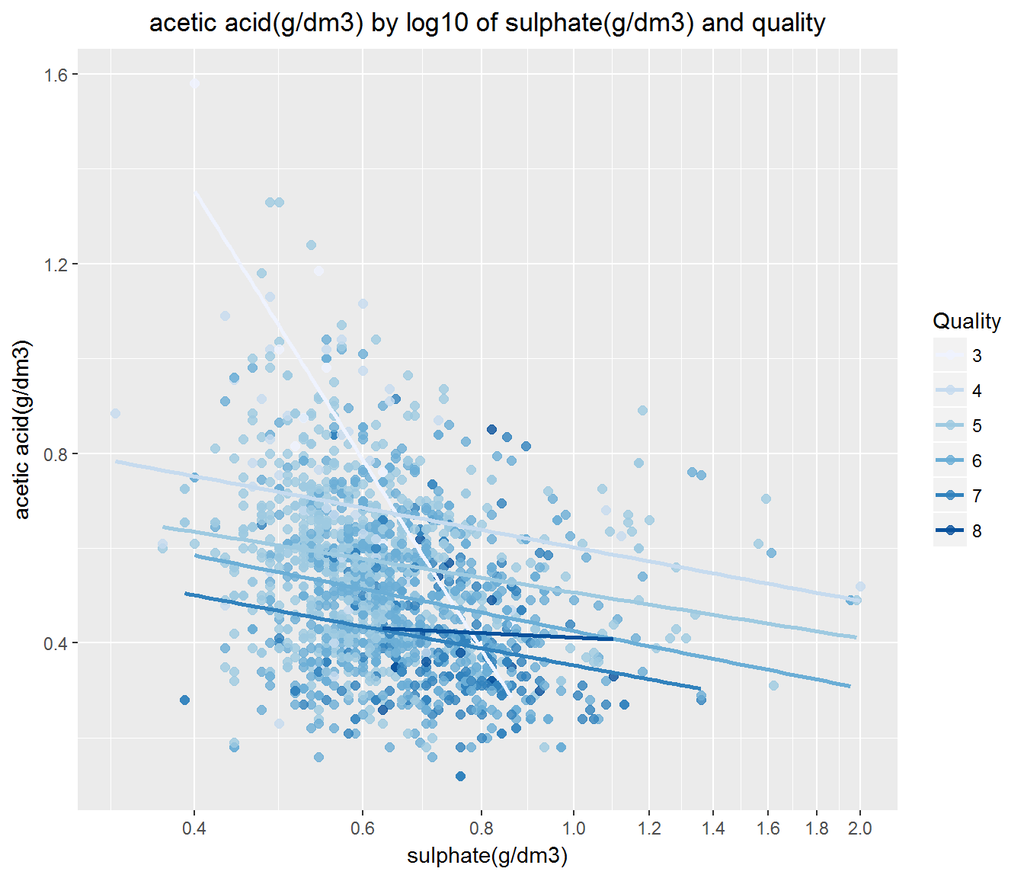

### Description three

By decreasing the amount of acetic acid(volatile acidity) and increasing the amount of sulphate, the quality of the red wine would increase. By increasing acetic acid and decreasing sulphate level the quality of the wine would become worse.

## Reflection:

This data set contains 1,599 red wines with 11 variables on the chemical properties of the wine. At least 3 wine experts rated the quality of each wine, providing a rating between 0 (very bad) and 10 (very excellent). For exploring this data set, we started with understanding the individual variables.Then we tried to understand which variables are related to quality. We first used bivariate analysis in which we used scatter plots of each variable against different levels of quality and found out that Fixed Acidity, volatile Acidity, alcohol, citric acid and sulphates have more correlation with quality than other variables. Then we created the correlation table for these variables and according to that table we figured out that alcohol, sulphates and volatile acidity have the most correlation with quality. We created bar plots and also box plots to show this correlation better. After doing bivariate analysis and limiting the options, we did multivariate analysis to find two variables that mostly describe the quality, after doing the log transformation, we figured out that sulphates and volatile acidity have approximately linear relationship with the quality. One of the issues with this model and the data set is that the number of data points for wines with good qualities (7 or 8) and wines with bad qualities (3 or 4) is much less than the medium quality. The model would have been more accurate if we had more data points for good and bad quality of red wines.So we suggest that for future exploration, more data for low and high levels of quality of the wine be collected to be able to present a better model.